# How to use R_cheat_sheet.pdf

## First, get the document from github

https://github.com/STATShunt/tia/blob/master/notes/misc_notes/R_cheat_sheet.pdf (click on the “download” button on the rhs)

## Start RStudio

And try to save your examples in an R script (in Rstudio go to File–>New File–>R Script).

## Practice on your own

``People have now-a-days got a strange opinion that everything should be taught by lectures. Now, I cannot see that lectures can do so much as reading the books from which the lectures are taken. I know nothing that can be best taught by lectures, except where experiments are to be shewn. You may teach chemistry by lectures:– You might teach the making of shoes by lectures!’’, attributed to Samuel Johnson by his biographer, Boswell.

## Below are some examples from the cheat sheet

## Page 1 examples

### help

Use help as a first resort.

```r
?mean  # help on the function to take averages (watch out for removing na's)
```

```
## starting httpd help server ... done
```

```r
?"$" # make sure to use quotes for special symbols
```

### what is in my objects?

```r
xlabs<- sample(c("high","low"),92, replace=TRUE)
set.seed(99)
xmeasurement<-rpois(92,10)
xplant<-data.frame(plantID=1:length(xlabs), fert=xlabs,height=xmeasurement)

str(xplant) # summary of what is in the data frame
```

```
## 'data.frame':    92 obs. of  3 variables:
##  $ plantID: int  1 2 3 4 5 6 7 8 9 10 ...
##  $ fert   : chr  "low" "low" "low" "high" ...
##  $ height : int  10 11 10 11 8 10 7 11 5 7 ...
```

```r
dim(xplant);ncol(xplant);nrow(xplant)  # check these in the help file ...
```

```
## [1] 92  3
```

```
## [1] 3
```

```
## [1] 92
```

```r
# View(xplant)
```

### working directory

See what is in your working directory.

```r
getwd()
```

```
## [1] "C:/Users/hunti/OneDrive - University of Tasmania/Documents/111_live/111_teaching/2022/KLA_201/R_markdown"
```

This is where files will be read and written by default (unless a specific file path is specified).

### vectors

```r
c(1,2,3,99)
```

```
## [1]  1  2  3 99
```

```r
1000:1010
```

```
##  [1] 1000 1001 1002 1003 1004 1005 1006 1007 1008 1009 1010
```

```r
set.seed(101)
x<-rnorm(10)
x
```

```
##  [1] -0.3260365  0.5524619 -0.6749438  0.2143595  0.3107692  1.1739663
##  [7]  0.6187899 -0.1127343  0.9170283 -0.2232594
```

```r
sort(x)  # put things in order
```

```
##  [1] -0.6749438 -0.3260365 -0.2232594 -0.1127343  0.2143595  0.3107692
##  [7]  0.5524619  0.6187899  0.9170283  1.1739663
```

#### Vector elements

Using element references and square brackets.

```r
x<-101:110

x[4]
```

```
## [1] 104
```

```r
x[-4]
```

```
## [1] 101 102 103 105 106 107 108 109 110
```

Vector elements with TRUE and FALSE

```r
x<-101:110

x[x==104]
```

```
## [1] 104
```

```r
x[!x==104]
```

```
## [1] 101 102 103 105 106 107 108 109 110
```

```r
x[-which(x==104)]
```

```
## [1] 101 102 103 105 106 107 108 109 110
```

```r
x%in%c(101,106)
```

```
##  [1]  TRUE FALSE FALSE FALSE FALSE  TRUE FALSE FALSE FALSE FALSE
```

```r
which(x%in%c(101,106))
```

```
## [1] 1 6
```

```r
x[x%in%c(101,106)]
```

```
## [1] 101 106
```

### reading and writing files

Read in raw file from GITHUB, formatted with columns set by a comma (assumes internet connection).

```r
xurl<-"https://raw.githubusercontent.com/STATShunt/tia/master/data/cannabis/data_buds.csv"
xbud<-read.csv(file=xurl,check.names = FALSE,stringsAsFactors =TRUE)

# now try writing xbud to your working directory
getwd() # look here for any files written
```

```
## [1] "C:/Users/hunti/OneDrive - University of Tasmania/Documents/111_live/111_teaching/2022/KLA_201/R_markdown"
```

```r
write.csv(xbud,file="myxbud_pesky_row_names.csv")
write.csv(xbud,file="myxbud.csv",row.names = FALSE) # no redundant row names!

# now try reading myxbud from your working directory
getwd() # look here for any files to load
```

```
## [1] "C:/Users/hunti/OneDrive - University of Tasmania/Documents/111_live/111_teaching/2022/KLA_201/R_markdown"
```

```r
xbud_new_wrong<-read.csv(file="myxbud_pesky_row_names.csv")
str(xbud_new_wrong)
```

```
## 'data.frame':    24 obs. of  11 variables:
##  $ X        : int  1 2 3 4 5 6 7 8 9 10 ...
##  $ Sample   : int  62 66 69 79 58 65 75 78 53 73 ...
##  $ treatment: int  1 1 1 1 2 2 2 2 3 3 ...
##  $ weight   : int  37 45 34 32 61 68 94 76 47 60 ...
##  $ CBDVA    : num  0.137 0.147 0.171 0.277 0.17 ...
##  $ CBD      : num  0.585 0.666 1.786 1.04 0.528 ...
##  $ CBDA     : num  3.17 3.81 4.02 5.77 4.04 ...
##  $ CBGA     : num  0.0476 0.0672 0.0832 0.1515 0.2906 ...
##  $ THCA     : num  0.108 0.1275 0.0872 0.1882 0.152 ...
##  $ CBC      : num  0.0433 0.0438 0.0931 0.069 0.0353 ...
##  $ CBCA     : num  0.111 0.136 0.137 0.228 0.151 ...
```

```r
xbud_new<-read.csv(file="myxbud.csv")
str(xbud_new) #check everything is exactly the same as xbud
```

```
## 'data.frame':    24 obs. of  10 variables:
##  $ Sample   : int  62 66 69 79 58 65 75 78 53 73 ...
##  $ treatment: int  1 1 1 1 2 2 2 2 3 3 ...
##  $ weight   : int  37 45 34 32 61 68 94 76 47 60 ...
##  $ CBDVA    : num  0.137 0.147 0.171 0.277 0.17 ...
##  $ CBD      : num  0.585 0.666 1.786 1.04 0.528 ...
##  $ CBDA     : num  3.17 3.81 4.02 5.77 4.04 ...
##  $ CBGA     : num  0.0476 0.0672 0.0832 0.1515 0.2906 ...
##  $ THCA     : num  0.108 0.1275 0.0872 0.1882 0.152 ...
##  $ CBC      : num  0.0433 0.0438 0.0931 0.069 0.0353 ...
##  $ CBCA     : num  0.111 0.136 0.137 0.228 0.151 ...
```

### functions

```r
fsum_simp<-function(x){
  out<-c(length(x),mean(x),sd(x))
  names(out)<-c("n","mean","sd")
  out #return(out) is equivalent
}

x<-rnorm(9)

fsum_simp(x)  # you get back what is in the variable "out" from the function
```

```
##          n       mean         sd
##  9.0000000 -0.2607157  0.8641977
```

## Page 2 examples

### variable types

```r
xl<-c(TRUE,FALSE)
str(xl)
```

```
##  logi [1:2] TRUE FALSE
```

```r
class(xl)
```

```
## [1] "logical"
```

```r
is.logical(xl)
```

```
## [1] TRUE
```

```r
as.numeric(xl)
```

```
## [1] 1 0
```

```r
as.character(xl)
```

```
## [1] "TRUE"  "FALSE"
```

```r
is.logical(as.character(xl))
```

```
## [1] FALSE
```

```r
xnum<-rnorm(9)
is.logical(xnum)
```

```
## [1] FALSE
```

```r
as.logical(xnum)
```

```
## [1] TRUE TRUE TRUE TRUE TRUE TRUE TRUE TRUE TRUE
```

```r
ls() # what is in the RAM for your R session (close R and these are gone)
```

```
##  [1] "fsum_simp"      "x"              "xbud"           "xbud_new"
##  [5] "xbud_new_wrong" "xl"             "xlabs"          "xmeasurement"
##  [9] "xnum"           "xplant"         "xurl"
```

```r
rm(list=ls())  # delete everything so you can start again (you saved the code to make everything again ...)
ls() # nothing there ...
```

```
## character(0)
```

### matrices

Matrices only hold data of one type - data frames and lists are more useful.

```r
matrix(1:12,ncol=4,nrow=3) # rows*cols=12 - looks correct
```

```
##      [,1] [,2] [,3] [,4]
## [1,]    1    4    7   10
## [2,]    2    5    8   11
## [3,]    3    6    9   12
```

```r
matrix(1:12,ncol=4,nrow=4) # beware default behaviour (is this what you want?)
```

```
##      [,1] [,2] [,3] [,4]
## [1,]    1    5    9    1
## [2,]    2    6   10    2
## [3,]    3    7   11    3
## [4,]    4    8   12    4
```

```r
x<-matrix(1:12,ncol=4,nrow=3)

x[1,] # first row ...
```

```
## [1]  1  4  7 10
```

```r
x[1:2,] # first two rows
```

```
##      [,1] [,2] [,3] [,4]
## [1,]    1    4    7   10
## [2,]    2    5    8   11
```

```r
x[1:2,2] # first two rows, second col
```

```
## [1] 4 5
```

```r
dim(x);nrow(x);ncol(x)
```

```
## [1] 3 4
```

```
## [1] 3
```

```
## [1] 4
```

### lists

Lists can hold data of different types AND of different shapes/lengths.

```r
l<-list(x=1:5,y=c("t1","t1","t2","t2","t2"))
length(l)
```

```
## [1] 2
```

```r
l[[2]]
```

```
## [1] "t1" "t1" "t2" "t2" "t2"
```

```r
ldf<-data.frame(height=l[[1]],treatment=l[[2]])
```

```r
ldiff<-list(x=1:5,y=c("t1","t2"))
ldiff
```

```
## $x
## [1] 1 2 3 4 5
##
## $y
## [1] "t1" "t2"
```

### data frames

Data frames can hold data of different types but each column must be the same length (so a data frame is a special rectangular matrix).

```r
x<-1:5
y<-c("t1","t1","t2","t2","t2")

ldf<-data.frame(x,treatment=y)
str(ldf)
```

```
## 'data.frame':    5 obs. of  2 variables:
##  $ x        : int  1 2 3 4 5
##  $ treatment: chr  "t1" "t1" "t2" "t2" ...
```

```r
ldf[1:2,]
```

```
##   x treatment
## 1 1        t1
## 2 2        t1
```

```r
colnames(ldf)
```

```
## [1] "x"         "treatment"
```

```r
colnames(ldf)%in%c("treatment")
```

```
## [1] FALSE  TRUE
```

```r
ldf$treatment
```

```
## [1] "t1" "t1" "t2" "t2" "t2"
```

```r
ldf[,colnames(ldf)%in%c("treatment")]
```

```
## [1] "t1" "t1" "t2" "t2" "t2"
```

```r
ldf[,colnames(ldf)%in%c("x","treatment","blah")]
```

```
##   x treatment
## 1 1        t1
## 2 2        t1
## 3 3        t2
## 4 4        t2
## 5 5        t2
```

### strings

```r
paste("hello","there")
```

```
## [1] "hello there"
```

```r
paste("treatment",1:5)
```

```
## [1] "treatment 1" "treatment 2" "treatment 3" "treatment 4" "treatment 5"
```

```r
paste("treatment",1:5,sep="_")
```

```
## [1] "treatment_1" "treatment_2" "treatment_3" "treatment_4" "treatment_5"
```

```r
paste("treatment",1:5,sep="")
```

```
## [1] "treatment1" "treatment2" "treatment3" "treatment4" "treatment5"
```

```r
paste0("treatment",1:5)
```

```
## [1] "treatment1" "treatment2" "treatment3" "treatment4" "treatment5"
```

### plots and random numbers

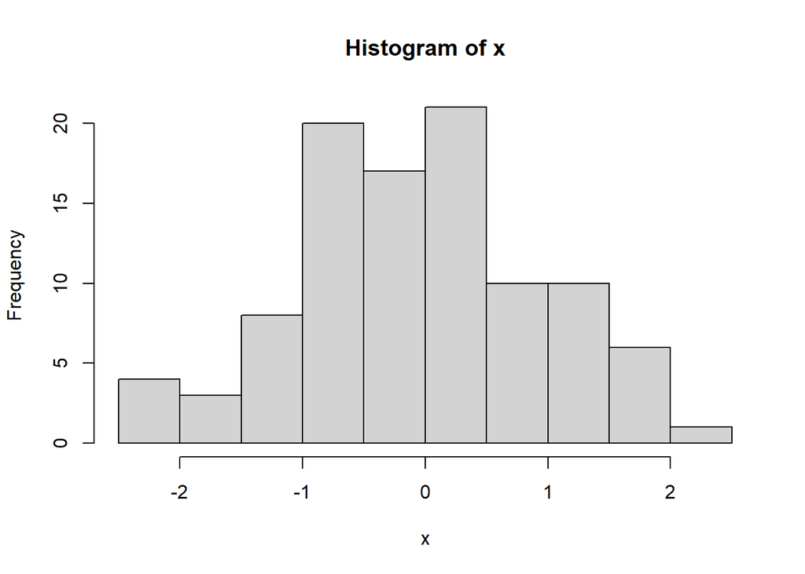

```r
x<-rnorm(100)
hist(x)
```

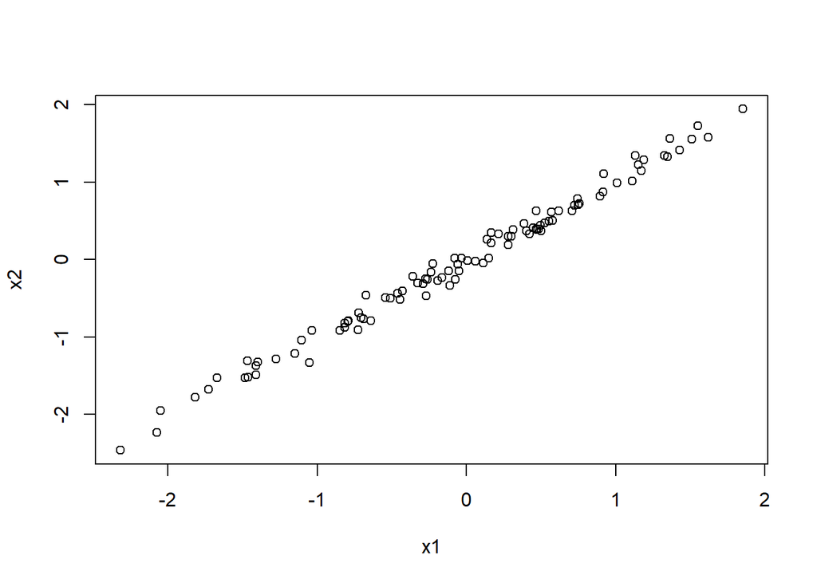

```r
set.seed(101)
x1<-rnorm(100)
x2<-x1+rnorm(100,sd=.1)  # x1 plus a little bit of noise
x3<-x1+rnorm(100,sd=1) # x1 plus more noise
x4<-x1+rnorm(100,sd=5) # x1 plus a lot of noise
x5<-rnorm(100,sd=1) # independent data, same mean and variance

plot(x1,x2) # scatter plot
```

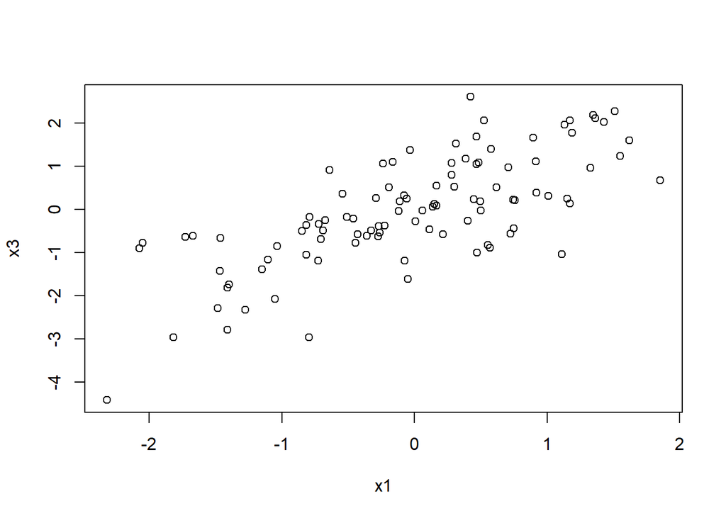

```r
plot(x1,x3)
```

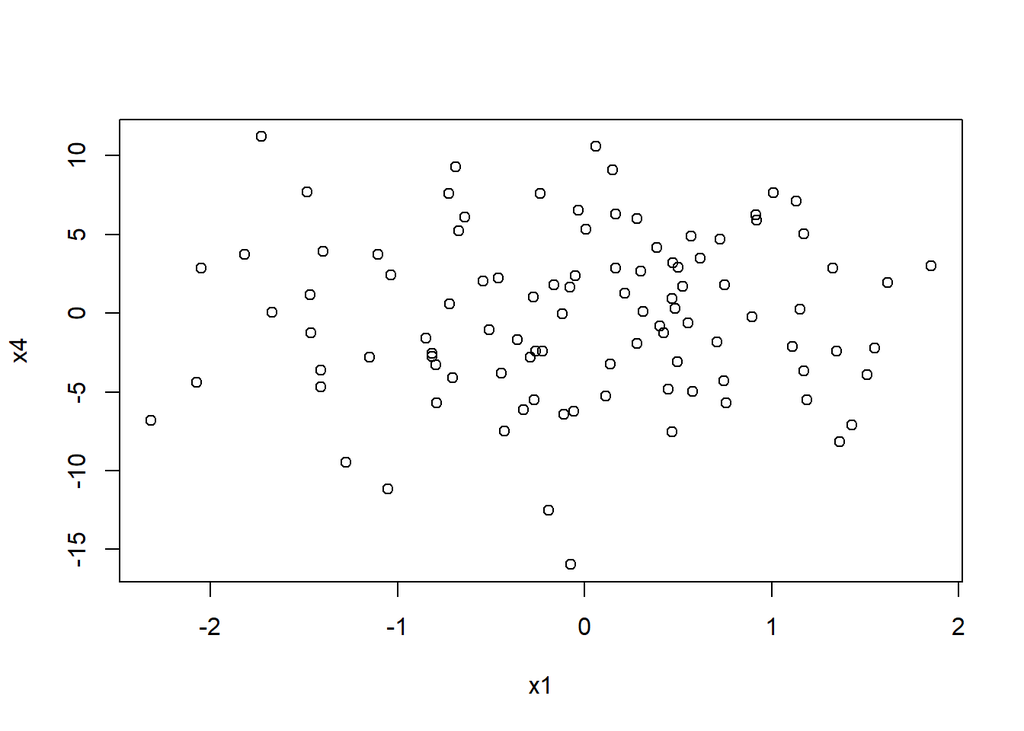

```r
plot(x1,x4)
```

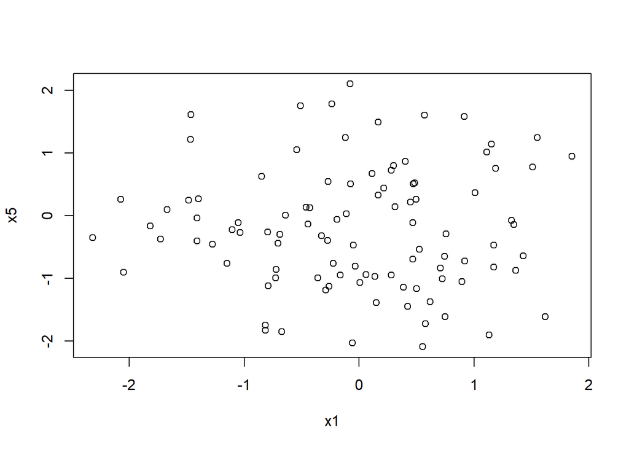

```r
plot(x1,x5)
```

```r
cor(x1,x2) # very high correlation
```

```
## [1] 0.9944649
```

```r
cor(x1,x3) # moderate correlation
```

```
## [1] 0.7291227
```

```r
cor(x1,x4) # low correlation
```

```
## [1] 0.02763427
```

```r
cor(x1,x5) # zero (true) correlation
```

```
## [1] -0.008034801
```